# Project: TMDb Movie Analysis

- Introduction
- Data Wrangling
- Exploratory Data Analysis
- Conclusions

## Introduction

In the following report I dive into international movie data in order to search for underlying trends in movie genres, number of releases and effects of different casts on the overall revenue of a movie etc. Findings from this analysis are merely taken by visualization and not using complex machine learning algorithms.

Questions asked:

- Which genres are most common for movies?
- Which directors led the most movies between 1960 and 2016? Is the number of movies per year increasing with the years?
- How does the budget effect user ratings? Are movies with a higher budget rated higher on average than low-budget productions?

### The TMDb dataset

The base dataset used for analysis is provided by TMDb, The Movie Database. The dataset is provided as a csv-file and contains movie data spanning from 1960-2015.

Link to dataset: https://d17h27t6h515a5.cloudfront.net/topher/2017/October/59dd1c4c_tmdb-movies/tmdb-movies.csv

```python
import numpy as np
import pandas as pd
import matplotlib.pyplot as plt
%matplotlib inline
```

## Data Wrangling

> **Tip**: In this section of the report, you will load in the data, check for cleanliness, and then trim and clean your dataset for analysis. Make sure that you document your steps carefully and justify your cleaning decisions.

### General Properties

Let's first have a look at the dataset to see what we are dealing with. We also plot the first couple of rows.

```python
df = pd.read_csv('tmdb-movies.csv')
df.head(3)
```

|  | id | imdb_id | popularity | budget | revenue | original_title | cast | homepage | director | tagline | ... | overview | runtime | genres | production_companies | release_date | vote_count | vote_average | release_year | budget_adj | revenue_adj |
| --- | --- | --- | --- | --- | --- | --- | --- | --- | --- | --- | --- | --- | --- | --- | --- | --- | --- | --- | --- | --- | --- |
| 0 | 135397 | tt0369610 | 32.985763 | 150000000 | 1513528810 | Jurassic World | Chris Pratt\|Bryce Dallas Howard\|Irrfan Khan\|Vi... | http://www.jurassicworld.com/ | Colin Trevorrow | The park is open. | ... | Twenty-two years after the events of Jurassic ... | 124 | Action\|Adventure\|Science Fiction\|Thriller | Universal Studios\|Amblin Entertainment\|Legenda... | 6/9/15 | 5562 | 6.5 | 2015 | 1.379999e+08 | 1.392446e+09 |
| 1 | 76341 | tt1392190 | 28.419936 | 150000000 | 378436354 | Mad Max: Fury Road | Tom Hardy\|Charlize Theron\|Hugh Keays-Byrne\|Nic... | http://www.madmaxmovie.com/ | George Miller | What a Lovely Day. | ... | An apocalyptic story set in the furthest reach... | 120 | Action\|Adventure\|Science Fiction\|Thriller | Village Roadshow Pictures\|Kennedy Miller Produ... | 5/13/15 | 6185 | 7.1 | 2015 | 1.379999e+08 | 3.481613e+08 |
| 2 | 262500 | tt2908446 | 13.112507 | 110000000 | 295238201 | Insurgent | Shailene Woodley\|Theo James\|Kate Winslet\|Ansel... | http://www.thedivergentseries.movie/#insurgent | Robert Schwentke | One Choice Can Destroy You | ... | Beatrice Prior must confront her inner demons ... | 119 | Adventure\|Science Fiction\|Thriller | Summit Entertainment\|Mandeville Films\|Red Wago... | 3/18/15 | 2480 | 6.3 | 2015 | 1.012000e+08 | 2.716190e+08 |

3 rows × 21 columns

```python
df.info()
```

```
<class 'pandas.core.frame.DataFrame'>
RangeIndex: 10866 entries, 0 to 10865
Data columns (total 21 columns):
 #   Column                Non-Null Count  Dtype
---  ------                --------------  -----
 0   id                    10866 non-null  int64
 1   imdb_id               10856 non-null  object
 2   popularity            10866 non-null  float64
 3   budget                10866 non-null  int64
 4   revenue               10866 non-null  int64
 5   original_title        10866 non-null  object
 6   cast                  10790 non-null  object
 7   homepage              2936 non-null   object
 8   director              10822 non-null  object
 9   tagline               8042 non-null   object
 10  keywords              9373 non-null   object
 11  overview              10862 non-null  object
 12  runtime               10866 non-null  int64
 13  genres                10843 non-null  object
 14  production_companies  9836 non-null   object
 15  release_date          10866 non-null  object
 16  vote_count            10866 non-null  int64
 17  vote_average          10866 non-null  float64
 18  release_year          10866 non-null  int64
 19  budget_adj            10866 non-null  float64
 20  revenue_adj           10866 non-null  float64
dtypes: float64(4), int64(6), object(11)
memory usage: 1.7+ MB
```

The dataset contains 10866 movies and 21 features.

From the overview we already see that some columns contain null-values. Null-values can cause issues during data processing and therefore need to be dealt with (see next chapter).

As not every feature is needed for this analysis, I am going to drop unnesessary columns. We are not interested in the columns `imdb_id`, `homepage`, `tagline`, `overview`, `keywords`, `release_date` (year is sufficient), `vote_count`. We also remove the columns `revenue` and `budget` as we will use the cost adjusted for inflation. We also drop `popularity` as we will use `vote_average` as a popularity score.

```python
columns = ["imdb_id", "homepage", "tagline", "overview", "keywords", "release_date", "vote_count", "revenue", "budget", "popularity", "keywords"]
df.drop(columns=columns, inplace=True)
df.head(2)
```

|  | id | original_title | cast | director | runtime | genres | production_companies | vote_average | release_year | budget_adj | revenue_adj |
| --- | --- | --- | --- | --- | --- | --- | --- | --- | --- | --- | --- |
| 0 | 135397 | Jurassic World | Chris Pratt\|Bryce Dallas Howard\|Irrfan Khan\|Vi... | Colin Trevorrow | 124 | Action\|Adventure\|Science Fiction\|Thriller | Universal Studios\|Amblin Entertainment\|Legenda... | 6.5 | 2015 | 1.379999e+08 | 1.392446e+09 |
| 1 | 76341 | Mad Max: Fury Road | Tom Hardy\|Charlize Theron\|Hugh Keays-Byrne\|Nic... | George Miller | 120 | Action\|Adventure\|Science Fiction\|Thriller | Village Roadshow Pictures\|Kennedy Miller Produ... | 7.1 | 2015 | 1.379999e+08 | 3.481613e+08 |

### Data Cleaning

First, the datatypes of `budget_adj` and `revenue_adj` seem off. To ease future analysis we will change the datatype to integer.

```python
df=df.astype({'budget_adj': 'int64', 'revenue_adj': 'int64'})
df.head(2)
```

|  | id | original_title | cast | director | runtime | genres | production_companies | vote_average | release_year | budget_adj | revenue_adj |
| --- | --- | --- | --- | --- | --- | --- | --- | --- | --- | --- | --- |
| 0 | 135397 | Jurassic World | Chris Pratt\|Bryce Dallas Howard\|Irrfan Khan\|Vi... | Colin Trevorrow | 124 | Action\|Adventure\|Science Fiction\|Thriller | Universal Studios\|Amblin Entertainment\|Legenda... | 6.5 | 2015 | 137999939 | 1392445892 |
| 1 | 76341 | Mad Max: Fury Road | Tom Hardy\|Charlize Theron\|Hugh Keays-Byrne\|Nic... | George Miller | 120 | Action\|Adventure\|Science Fiction\|Thriller | Village Roadshow Pictures\|Kennedy Miller Produ... | 7.1 | 2015 | 137999939 | 348161292 |

We can work with the remaining columns now. For genre analysis, we might split the items in the future.

Let us now have a look at the rows to ensure we have a complete dataset. First, we do not want to include duplicate rows in our dataset.

```python
sum(df.duplicated())
```

```
1
```

Luckily, there is only a single duplicate data in the set. We can savely remove it from the dataset.

```python
df.drop_duplicates(inplace=True)
sum(df.duplicated())
```

```
0
```

```python
df.isnull().sum()
```

```
id                         0
original_title             0
cast                      76
director                  44
runtime                    0
genres                    23
production_companies    1030
vote_average               0
release_year               0
budget_adj                 0
revenue_adj                0
dtype: int64
```

We see that some columns have still NULL values. Nevertheless all these values can be attributed to names of directors, actors or production companies. For the first analysis questions, this missing data is not considered and therefor can be kept. For aggregation, null values are replaced by empty strings.

```python
df.genres.fillna('',inplace=True)
df.genres.replace(np.NaN,'',inplace=True)
df.production_companies.fillna('',inplace=True)
df.cast.fillna('',inplace=True)
df.isnull().sum()
```

```
id                       0
original_title           0
cast                     0
director                44
runtime                  0
genres                   0
production_companies     0
vote_average             0
release_year             0
budget_adj               0
revenue_adj              0
dtype: int64
```

Data cleaning is now complete. We will save the cleaned data to a new dataframe which will be used for exploratory data analysis.

```python
df_clean = df.copy()
```

## Exploratory Data Analysis

### Research question 1: Which genres are most common for movies?

The `genres` column contains multiple values stored as a string. Let us first create a function to split the string into a list of strings.

```python
## reusable function to divide feature values into a list of separate strings, e.g. 'abc|def|gh' into ['abc','def','gh']. NaN are ignored.
def splitColumn(col, sep = ','):
    return col[col.notnull()].apply(lambda x: x.split(sep)).sum()
```

Let us now use this function to separate the genres, which are stored as a combined string where genres of a single movie are separated by '|'. We then visualizie the resulting frequency distribution using a barplot.

```python
genres = splitColumn(df_clean.genres,'|')
df_genres = pd.DataFrame(genres,columns=["genre"])

df_genres.value_counts()
```

```
genre
Drama              4760
Comedy             3793
Thriller           2907
Action             2384
Romance            1712
Horror             1637
Adventure          1471
Crime              1354
Family             1231
Science Fiction    1229
Fantasy             916
Mystery             810
Animation           699
Documentary         520
Music               408
History             334
War                 270
Foreign             188
TV Movie            167
Western             165
dtype: int64
```

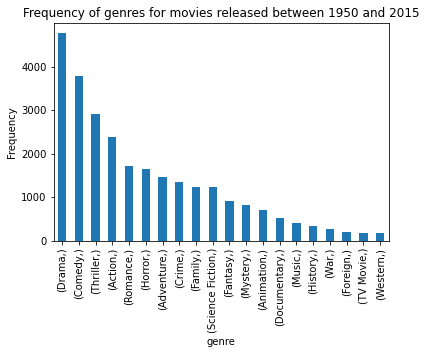

```python
df_genres.value_counts().plot(kind='bar',ylabel = "Frequency", title="Frequency of genres for movies released between 1950 and 2015")
```

From the barplot we see that during the given timeframe the genre `Drama` (4760 movies) is most common followed by `Comedy` (3793) and `Thriller` (2907).

### Research question 2: Which directors led the most movies between 1960 and 2016? Is the number of movies per year increasing with the years?

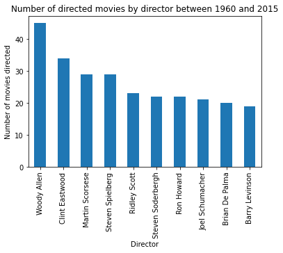

```python
df_clean.director.value_counts()[:10].plot(kind="bar", title="Number of directed movies by director between 1960 and 2015", xlabel="Director", ylabel="Number of movies directed")
```

Seems like `Woody Allen` has directed the most movies during the given time period (45). He is followed by the directors `Clint Eastwood`, `Martin Scorsese` and `Steven Spielberg`.

Let us now have a look at the evolution of movie releases per year during over the dataset.

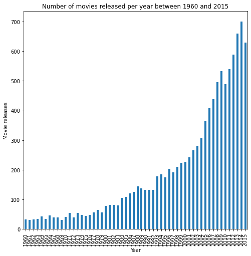

```python
df_clean.groupby('release_year')['original_title'].count().plot(kind="bar", title="Number of movies released per year between 1960 and 2015", xlabel = "Year", ylabel = "Movie releases", figsize=(8,8))
```

Given the plot above it is clear that the number of movie releases per year is increases. It might as well indicate exponential increase.

### Research question 3: How does the budget effect user ratings? Are movies with a higher budget rated higher on average than low-budget productions?

The second question states, if user ratings are correlated to the movie budget, i.e. if good user ratings can be "bought".

Let us first have a look at the general distribution of user votes:

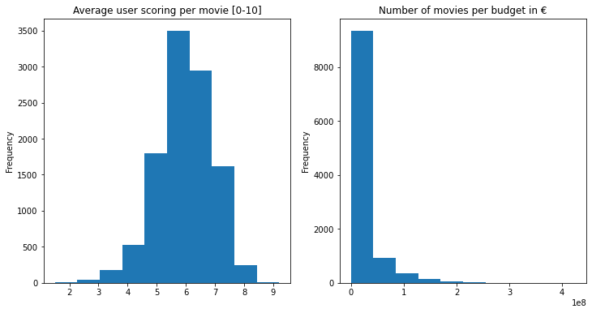

```python
ax1 = plt.subplot(121)
ax2 = plt.subplot(122)
ax1.set_xlabel="Average scoring"
ax2.set_xlabel="Budget in €"
df_clean["vote_average"].plot(kind="hist", ax=ax1, figsize=(12,6),title="Average user scoring per movie [0-10]")
df_clean["budget_adj"].plot(kind="hist", ax=ax2, title="Number of movies per budget in €")
```

```python
df_clean["vote_average"].describe()
```

```
count    10865.000000
mean         5.975012
std          0.935138
min          1.500000
25%          5.400000
50%          6.000000
75%          6.600000
max          9.200000
Name: vote_average, dtype: float64
```

User votings seem to follow a nice bell curve with an average score of 6. Let us now plot the two features against each other in a scatter plot.

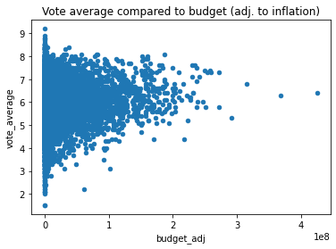

```python
df_clean.plot.scatter(x="budget_adj",y="vote_average", title="Vote average compared to budget (adj. to inflation)")
```

Using the scatterplot a dependency between the two features cannot be seen immediately. Let us therefore compute also the correlation using the Pearson method.

```python
df_clean["vote_average"].corr(df_clean["budget_adj"], method="pearson")
```

```
0.09307902480861735
```

As the Pearson correlation coefficient is positive, but very close to zero, one cannot state a strong correlation between used budget and user ratings. Nevertheless movies with a budget over 200.000.000 € tend to have a rating above 5, but this might also be caused by a smaller sample size in this budget category.

This indicates that user ratings cannot be bought by special effects and an expensive cast alone.

### Research question 3: Tend viewers to rate older movies differently than modern movies?

Let us now see, if modern movies are rated differently compared to older movies.

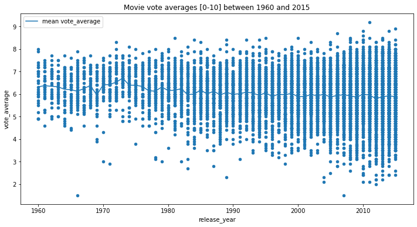

```python
ax=df_clean.groupby("release_year")["vote_average"].mean().plot(kind="line", figsize=(12,6), label="mean vote_average", legend="mean")
df_clean.plot.scatter(x="release_year", y="vote_average", title="Movie vote averages [0-10] between 1960 and 2015", ax=ax)
```

```python
df_clean["release_year"].corr(df_clean["vote_average"])
```

```
-0.11757558609467537
```

As correlation value and the plotted mean votes over the past years show there is a slight negative correlation between `vote_average` and `release_year`. Over the past years, one can see a slight decrease in the average user ratings. This of course is only correlation, not causility. Reasons might be that old movies tend to be classics and are therefore rated higher. Another reason might be that nowerdays movies are produced in great quantities, where some producers might prefer quantity instead of quality. Both reasons might cause the effect...or none of them...

## Conclusions

We conclude this dataset analysis by saying that the number of movie releases per year has been increasing steadily since the 1970s and might keep increasing in the future. `Woody Allen` is the director with the overall most movie releases between 1960 and 2015. Furthermore user ratings seem to not depend on the money spent producing the movie (`budget_adj`), so money does not equal quality. Lastly there is an indication that the viewer `vote_average` is decreasing over the years, but there is only slight correlation and causality is only part of speculaiton.

### Limitations

The dataset is limited in some sense. First of all there is no given description for each column. Most of the columns are self-explanatory, but for some columns additonal information might be helpful. This is especially the case for columns `budget_adj` and `revenue_adj` as the currency is not provided and might also differ among differnt movies. Secondly, the dataset is not up-to-date as it does not contain movies between 2016 and 2021. Stated trends from the analysis might not be correct or even reversed when most current movies are included in the dataset. Of course, all conducted analysis so far is only descriptive. As we do not have access to the full set of movies, we would need to conduct inferential statistics to see how valid our observations are for the full population.